# Email Marketing Technical Report

#### Authors: Bea Sauve, Kainen Osborne, Elton Nichols

#### Course: CSB304 H10 31429 Data Analytics in Business

#### Instructor: Eric Lloyd

## *Business Objective*

During 2004, Timeless Transport Models began running an A/B test email marketing experiment to improve customer engagement and sales. The test involves observations of customer interactions between Conversational type emails and Alarming type emails. The tests were also conducted in two phases. From January-March each email type was sent on wednesday, and from March-July each email type was sent on Monday, Wednesday, and Friday. Analytical methods include comparisons between click rates, open rates, unsubscribe rates, and order rates between the two states of emails. Hypothetical tests regarding the statistical significance between the email types and unsubscribe rates, and correlations between customer orders and sales were also conducted to provide support toward our analytical observations.Based on our findings we determined that Conversational Type emails engage our customers consistently and are the highest contributor to our sales of the two groups. While Alarming emails produce the most customer engagement, they lead to majority of our customers unsubscribing, and don’t contribute as much as Conversational type emails towards our sales.

## *Expected Uses*

This experiment should be used to determine the most optimal tone of email to use and the effects they had on our customers, how frequency of sending emails affects customer engagement, and additional tests that may need implementation for refined results. Unsubscribe rates help us determine which email type leads to the lack of interest from our customers. Click rates give us insight on which emails drive the most attention to our clients. Open rates and Order rates provide details on which emails are driving customer engagement. Data regarding our order dates give us insight on the best days to send emails. With these results we can deduce the metrics that drive the most customer engagement from our email types, and establish the best days to send emails, resulting in higher sales. If there appears to be discrepancies within the analysis, or information that stands out, further A/B tests can be conducted to refine the details that raise questions..

## *Data Dictionary*

### Import libraries

Listed below are the libraries that will be used for our analysis

Ensure all packages have been successfully installed before attempting to import library packages. If you plan on running this Project Notebook, and do not have these packages installed navigate to the R Studio Console and copy/paste the install package you do not yet have.

#### Library Packages to Install

```r
install.packages("readr")      # Used to read and import data
install.packages("tidyverse")  # Used to create data visualizations
install.packages("scales")     # Used to format visualizations
install.packages("lubridate")  # Used for weekday conversion
install.packages("showtext")   # Used for importing fonts
install.packages("dplyr")      # Used to build summary dataframes
install.packages("pwr")        # Used in hypothesis testing
install.packages("car")        # Used for regression diagnostics
install.packages("effsize")     # Used to calculate effect sizes (Cohen's d, etc.)
install.packages("showtext")   # Used for importing and rendering custom fonts
```

#### Library Packages to Load

```r
library(readr)
library(tidyverse)
library(scales)
library(lubridate)
library(showtext)
library(dplyr)
library(pwr)
library(car)
library(effsize)
library(showtext)
```

## *Data Refinement*

Before we conduct any statistical analysis we must first import datasets, clean our data, and calculate statistics of the data. Post refinement, analytics will be conducted to provide insights on our A/B tested email types.

### Data Implementation and Cleaning

An accurate analysis can only be conducted with properly cleaned and implemented data. Our data implementation and cleaning includes importing data, properly formatting the data, merging data sources, and calculating analytical fields. Our Project Manager, Bea, and Kainen implemented and refined these data sets. Excluding the “sales_data_sample_cleaned.csv”, cleaned by our Version Control Manager, Elton, which was refined during the production of a separate analysis for Timeless Transport Models. All implementations of code within this document are contain the authors name in the code chunk.

#### Import Datasets

Next we will import the primary data sets to conduct our analysis. The primary files that we will be using are “email_metrics.csv”, containing accumulated data regarding email types, order dates, and customer engagement, “last_email_before_order.csv”, containing data regarding order details and the email type sent before the order was placed, and “sales_data_sample_cleaned.csv”, contains pre-cleaned data regarding our clientele and sales over the course of three years.

These Data sets are implemented with formatting, converting objects to doubles, and dates into a date format.

```r
email_metrics <- read_csv(
  "CSV/email_metrics.csv",
  col_types = cols(
    date_email_sent = col_date(format = "%Y-%m-%d"),
    day_of_week = col_double(),
    emails_sent = col_double(),
    number_opens = col_double(),
    number_unsub = col_double()
  )
)

last_email_before_order <- read_csv(
  "CSV/last_email_before_order.csv",
  col_types = cols(
    ORDERDATE = col_date(format = "%Y-%m-%d"),
    date_email_sent = col_date(format = "%Y-%m-%d")
  )
)

sales_data <- read_csv("CSV/sales_data_sample_cleaned.csv")
```

#### Data Cleaning

Our sales data contained an error where North America was interpreted as N/A, some columns had blank labels, and our “last email before sales” data contained duplicates. Below is how we refined the data to remove these errors.

```r
# swap n/a to NA in Territory
sales_data$TERRITORY[is.na(sales_data$TERRITORY)] <- "NA"

# Rename indexed nums in last email
names(last_email_before_order)[names(last_email_before_order) == "...1"] <- "X"

# Remove indexed nums from email metrics
email_metrics <- email_metrics %>% select(-"...1")

# Remove duplicated data
last_email_before_order_cleaned = subset(last_email_before_order, last_email_before_order$X != 8984)

# Remove the duplicate in email metrics by setting the sale to 0
email_metrics[email_metrics$email_subject == "TIME-SENSITIVE: LAST CHANCE FOR FEBRUARY’S HOTTEST PICKS!", "number_orders"] <- 0
```

#### Joining Datasets

We want to create a full picture of the data we collected. We will be creating a bigger picture of the impact each email type has on our sales. Both “Sales data” and “last email before order” contain sale dates and order numbers. We will be joining the two sets based on this information. “last email before order” and “email metrics” also have several overlaps between email sent dates, group types, and email types. We will combine elements of the sales data with the last email data to create a “last email with sales” dataset. This set will then be combined with “email metrics” to produce a cohesive dataset with sales and order information.

```r
# Accumulate all sales by order number
sales_by_order <- sales_data %>% group_by(ORDERNUMBER) %>% summarise(Total_Sales = sum(SALES))

# Add the order sales to email metrics based on order number
last_email_with_sales <- merge(last_email_before_order_cleaned,sales_by_order, by= "ORDERNUMBER")

# Group email sales by the day the emails were sent
sale_amount_per_email <- aggregate(list(sales_amount = last_email_with_sales$Total_Sales), by=list(group = last_email_with_sales$group, date_email_sent= last_email_with_sales$date_email_sent), FUN = sum)

# Add sales per email to email metrics
email_metric_with_sales = merge(email_metrics, sale_amount_per_email, by = c("group", "date_email_sent"), all.x = TRUE)

# Convert NA values to 0
email_metric_with_sales[is.na(email_metric_with_sales)] <- 0
```

#### Calculating Metrics

To create a clear picture of customer engagement with emails we would like to know the rates at which customers are clicking on emails, unsubscribing, opening our website links, and placing orders. Determining the span of time between an email sent date and an order date is also an important feature to determine the urgency in which people are placing orders. Below is our implementation of the metric rates and calculations between the date an email was sent and an order was placed.

##### Implement Marketing Metrics

We would like to determine the varying rates between the types of data collected. these rates include open, click, and order ratios to emails sent, open to click ratios, and sales amounts.

- Open Rate = Number opens / Number emails sent
- Click Rate = Number clicks / Number emails sent
- Open to Click Rate = Number click / Number opens
- Unsubscribe Rate = Number unsubs / Number emails sent
- Order Rate = Number order / Number emails sent
- Sales amount

```r
# Function to implement division across columns
calc_rates <- function(num_col, denom_col){
  email_metric_with_sales[num_col]/email_metric_with_sales[denom_col]}

#Open to click rate ratio
email_metric_with_sales["open_to_click_rate"] <- calc_rates("number_clicks","number_opens")

# Actions list to loop through and calculate metrics
actions <- list("opens","clicks","unsub","orders")

# Loop through actions, creating columns and calculating metrics
for(action in actions) {
  num_col_name <- paste(action, "_rate", sep= "")
  num_col <- paste("number_", action, sep = "")
  email_metric_with_sales[num_col_name] <- calc_rates(num_col, "emails_sent")
}
```

##### Implement a summary of days before an order was placed

Part of our analysis entails observations of days that customers placed orders. We calculated the difference between email send dates and order dates to conduct an analysis on the preferred days to place orders.

```r
# Define day of week order was placed
last_email_with_sales$order_day_of_week <-
  wday(as.Date(last_email_with_sales$ORDERDATE),
           label = TRUE,
           abbr = TRUE)

# Calculate differences between email sent and order placed
last_email_with_sales$days_before_order <-
  as.numeric(difftime(last_email_with_sales$ORDERDATE,
                    last_email_with_sales$date_email_sent,
                      units = "days"))

# Summarize days before order to prepare for merging with email metrics
days_summary <- last_email_with_sales %>%
  group_by(group, date_email_sent, email_subject, before_march, day_of_week) %>%
  summarise(
    avg_days_before_order = mean(days_before_order, na.rm = TRUE),
    .groups = "drop"
  )
# Merge the summarized data into email metrics, keep NA values
email_metric_with_sales <- email_metric_with_sales %>%
  left_join(
    days_summary,
    by = c("group", "date_email_sent", "email_subject",
           "before_march", "day_of_week"))
```

#### Creating Clarity within Columns

We included additional modifications to the naming conventions within the columns. The renaming within variables allows for clarity during the visualization process. This was also implemented very last within our data refinement to avoid obstructions within data calculations and merges.

```r
# Convert days of week to actual days
email_metric_with_sales$day_of_week <- factor(
  email_metric_with_sales$day_of_week,
  levels = c(0,2,4),
  labels = c("Mon", "Wed", "Fri"))

# Rename Groups
email_metric_with_sales$group <- factor(
  email_metric_with_sales$group,
  levels = c("Group A","Group B"),
  labels = c("Conversational", "Alarming"))
email_metric_with_sales$group_code <- factor(
  email_metric_with_sales$group_code,
  levels = c("Group A","Group B",
             "Group A0","Group A2","Group A4",
             "Group B0","Group B2","Group B4"),
  labels = c("Conversational", "Alarming",
             "Converse Mon","Converse Wed","Converse Fri",
             "Alarm Mon","Alarm Wed","Alarm Fri"))
last_email_with_sales$group <- factor(
  last_email_with_sales$group,
  levels = c("Group A","Group B"),
  labels = c("Conversational", "Alarming"))
```

#### Data Prep

Before conducting our visualizations, we establish a set of variables and summary datasets that will be referenced throughout the analysis. This includes phase labels splitting campaigns into Pre-March and Post-March periods, tone labels mapping Group A to Conversational and Group B to Alarming, and key rate calculations such as open rate, unsubscribe rate, and order rate. We also build the territory and product line pipelines by linking 2004 sales data to email sends through order numbers, and compute summary tables for revenue by territory, revenue by product line, and monthly sales. These objects are defined here once so that all subsequent visualization and analysis chunks can reference them without redundancy.

```r
# Phase and tone color palettes
phase_colors <- c("Pre-March" = "skyblue4", "Post-March" = "orange3")
tone_colors  <- c("Conversational" = "skyblue4", "Alarming" = "orange3")

# Weekday, month, phase, and tone labels
email_metrics <- email_metrics %>%
  mutate(
    weekday_label = factor(
      weekdays(date_email_sent),
      levels = c("Monday","Tuesday","Wednesday","Thursday","Friday","Saturday","Sunday")
    ),
    month_label = floor_date(date_email_sent, "month"),
    phase = factor(
      ifelse(date_email_sent < as.Date("2004-03-01"), "Pre-March", "Post-March"),
      levels = c("Pre-March", "Post-March")
    ),
    tone = case_when(
      group == "Group A" ~ "Conversational",
      group == "Group B" ~ "Alarming",
      TRUE               ~ "Unknown"
    )
  )

# Open and unsub rates
email_metrics <- email_metrics %>%
  mutate(
    open_rate  = ifelse(emails_sent == 0, NA, number_opens / emails_sent),
    unsub_rate = ifelse(emails_sent == 0, NA, number_unsub / emails_sent)
  )

# Order rate
if ("number_orders" %in% names(email_metrics)) {
  email_metrics <- email_metrics %>%
    mutate(order_rate = ifelse(emails_sent == 0, NA, number_orders / emails_sent))
} else {
  email_metrics$order_rate <- NA
}

# Overall average unsub rate
overall_avg <- mean(email_metrics$unsub_rate, na.rm = TRUE)

# Monthly unsub rates
monthly_unsub <- email_metrics %>%
  group_by(month_label) %>%
  summarise(
    avg_unsub_rate = mean(unsub_rate, na.rm = TRUE),
    n_sends        = n(),
    .groups = "drop"
  )

# Unsub rate by tone summary
tone_summary <- email_metrics %>%
  filter(group %in% c("Group A", "Group B")) %>%
  mutate(tone = ifelse(group == "Group A", "Conversational", "Alarming")) %>%
  group_by(tone) %>%
  summarise(
    mean_unsub = mean(unsub_rate, na.rm = TRUE),
    se_unsub   = sd(unsub_rate, na.rm = TRUE) / sqrt(n()),
    n_sends    = n(),
    .groups = "drop"
  )

# Unsub vs open rate medians
open_med  <- median(email_metrics$open_rate,  na.rm = TRUE)
unsub_med <- median(email_metrics$unsub_rate, na.rm = TRUE)

# Sales data mutations (2004 only)
sales_data <- sales_data %>%
  mutate(
    ORDERDATE   = as.Date(ORDERDATE, format = "%m/%d/%Y"),
    order_month = floor_date(ORDERDATE, "month"),
    REVENUE     = QUANTITYORDERED * PRICEEACH
  )

# Monthly revenue (2004 only)
monthly_sales <- sales_data %>%
  filter(YEAR_ID == 2004) %>%
  group_by(order_month) %>%
  summarise(
    total_revenue = sum(REVENUE, na.rm = TRUE),
    total_orders  = n_distinct(ORDERNUMBER),
    .groups = "drop"
  )

avg_monthly_rev <- mean(monthly_sales$total_revenue)

# Sales distribution stats
max_count  <- max(hist(sales_data$REVENUE,
                       breaks = seq(0, max(sales_data$REVENUE) + 500, 500),
                       plot = FALSE)$counts)
rev_median <- median(sales_data$REVENUE, na.rm = TRUE)
rev_mean   <- mean(sales_data$REVENUE,   na.rm = TRUE)
rev_q75    <- quantile(sales_data$REVENUE, 0.75, na.rm = TRUE)

# Territory pipeline — links territory/product to order number (2004 only)
territory_by_order <- sales_data %>%
  filter(YEAR_ID == 2004) %>%
  group_by(ORDERNUMBER, TERRITORY, PRODUCTLINE) %>%
  summarise(Total_Sales = sum(SALES), .groups = "drop")

# Link to last email sent by order number
last_email_with_territory <- merge(
  last_email_before_order_cleaned,
  territory_by_order,
  by = "ORDERNUMBER"
)

# Aggregate to group/date level
territory_per_email <- aggregate(
  list(sales_amount = last_email_with_territory$Total_Sales),
  by = list(
    group           = last_email_with_territory$group,
    date_email_sent = last_email_with_territory$date_email_sent,
    TERRITORY       = last_email_with_territory$TERRITORY,
    PRODUCTLINE     = last_email_with_territory$PRODUCTLINE
  ),
  FUN = sum
)

# Merge territory data onto email metrics with sales
email_metrics_territory <- merge(
  email_metric_with_sales,
  territory_per_email,
  by = c("group", "date_email_sent"),
  all.x = TRUE
)
email_metrics_territory[is.na(email_metrics_territory$sales_amount.y), "sales_amount.y"] <- 0

# Revenue by territory summary
revenue_by_territory <- email_metrics_territory %>%
  group_by(TERRITORY) %>%
  summarise(
    total_revenue = sum(sales_amount.y, na.rm = TRUE),
    n_orders      = n_distinct(group),
    .groups = "drop"
  ) %>%
  filter(total_revenue > 0) %>%
  mutate(
    pct_total = total_revenue / sum(total_revenue),
    TERRITORY = reorder(TERRITORY, total_revenue)
  )

# Revenue by product line summary
revenue_by_product <- email_metrics_territory %>%
  group_by(PRODUCTLINE) %>%
  summarise(
    total_revenue = sum(sales_amount.y, na.rm = TRUE),
    .groups = "drop"
  ) %>%
  filter(total_revenue > 0) %>%
  mutate(
    pct_total   = total_revenue / sum(total_revenue),
    PRODUCTLINE = reorder(PRODUCTLINE, total_revenue)
  )

# Adds tone and phase
email_metric_with_sales <- email_metric_with_sales %>%
  mutate(
    tone = case_when(
      group == "Conversational" ~ "Conversational",
      group == "Alarming"       ~ "Alarming",
      TRUE                      ~ "Unknown"
    ),
    phase = factor(
      ifelse(date_email_sent < as.Date("2004-03-01"), "Pre-March", "Post-March"),
      levels = c("Pre-March", "Post-March")
    )
  )
```

### Setting the theme

For the ease of visualization and cohesion, we implement concrete formatting for our visualizations. This formatting allows for consistent construction of our visualization, and reduces the need to manually customize our visualizations unless necessary.

```r
font_add_google("Old Standard TT", "old") # Downloads Roboto from Google
showtext_auto()
theme_set(
  theme_minimal(base_family = "old")+
    theme(
      plot.background = element_rect(fill = "white", color = NA),
      plot.subtitle = element_text(hjust = 0.5),
      plot.caption  = element_text(hjust = 0.5),
      plot.title = element_text(face = "bold", size = 14, hjust = 0.5)
    )
)
scale_colour_discrete <- function(...) {
  scale_colour_manual(values = c("skyblue4","orange3"))
}

scale_fill_discrete <- function(...) {
  scale_fill_manual(values = c("skyblue4","orange3"))
}
update_geom_defaults("line", list(size = 1.2))
update_geom_defaults("point", list(size = 3))
```

## *Data Statistics*

With the our data now refined and condensed our analysis may be conducted. R Studio has a built in “summary()” function that can be used for a quick synapses of the data we refined. The primary data sets that we will use for the conduction of our A/B analysis are “last email with sales” and “email metric with sales”

However, Our sales entail two email types and two phases. Therefore, we have created a custom summary statistics table, grouped by our phase status “before_march”, the day of the week, and our email types defined as “group”. This summary table contains similar calculations to the Summary function, returns averages of our calculated rates, and includes total values of our statistics. This information will be used for generic analysis deductions and has been used as a tool to verify correctness of data visualizations.

| before_march | group | emails_sent_Min | emails_sent_Q1 | emails_sent_Median | emails_sent_Mean | emails_sent_Q3 | emails_sent_Max | emails_sent_Total | number_clicks_Min | number_clicks_Q1 | number_clicks_Median | number_clicks_Mean | number_clicks_Q3 | number_clicks_Max | number_clicks_Total | number_opens_Min | number_opens_Q1 | number_opens_Median | number_opens_Mean | number_opens_Q3 | number_opens_Max | number_opens_Total | open_to_click_rate_Min | open_to_click_rate_Q1 | open_to_click_rate_Median | open_to_click_rate_Mean | open_to_click_rate_Q3 | open_to_click_rate_Max | open_to_click_rate_Total | … |
| --- | --- | --- | --- | --- | --- | --- | --- | --- | --- | --- | --- | --- | --- | --- | --- | --- | --- | --- | --- | --- | --- | --- | --- | --- | --- | --- | --- | --- | --- | --- |
| FALSE | Conversational | 29 | 30 | 32.0 | 31.46154 | 33 | 33 | 1227 | 0 | 1.00 | 1.0 | 1.2051282 | 2.00 | 3 | 47 | 0 | 1.00 | 2.0 | 2.025641 | 3.0 | 5 | 79 | 0.00000000 | 0.3333333 | 1.0000000 | 0.6671053 | 1.0000000 | 1.0000000 | 25.350000 | … |
| FALSE | Alarming | 21 | 24 | 25.0 | 25.71795 | 28 | 31 | 1003 | 0 | 0.00 | 1.0 | 0.7435897 | 1.00 | 2 | 29 | 0 | 1.00 | 2.0 | 2.538462 | 3.5 | 8 | 99 | 0.00000000 | 0.0000000 | 0.3333333 | 0.4362934 | 1.0000000 | 1.0000000 | 16.142857 | … |
| TRUE | Conversational | 102 | 102 | 102.0 | 102.00000 | 102 | 102 | 816 | 4 | 4.75 | 5.0 | 6.0000000 | 7.25 | 10 | 48 | 10 | 11.75 | 18.5 | 18.375000 | 23.5 | 29 | 147 | 0.16000000 | 0.2758799 | 0.3286638 | 0.3695114 | 0.4375000 | 0.7272727 | 2.956091 | … |
| TRUE | Alarming | 95 | 98 | 99.5 | 99.25000 | 101 | 102 | 794 | 3 | 3.00 | 4.5 | 4.3750000 | 5.25 | 6 | 35 | 14 | 21.50 | 26.0 | 27.000000 | 31.0 | 42 | 216 | 0.07142857 | 0.1205357 | 0.1869565 | 0.1833667 | 0.2162698 | 0.3529412 | 1.466934 | … |

### Click Rate Statistics

For the construction of this project we needed to break down the visualizations of the data into Before March and After March halves, each of those halves broken down into the Conversational and Alarming strategy categories. Elton worked on the construction and analysis of the click rate metrics. We want to analyze our click rates, number of clicks to emails sent. This analysis will assist in the determination of which email type is driving the most attention to our customers.

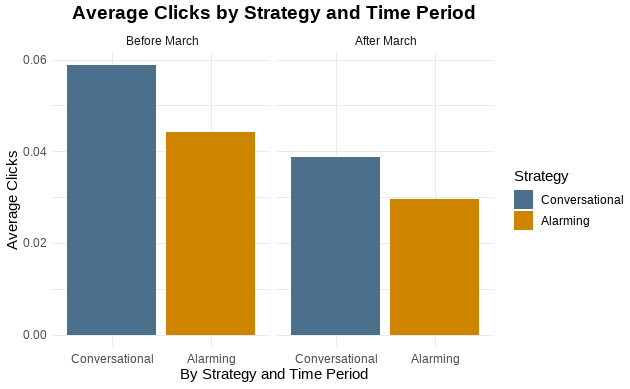

The chart showing Average Clicks indicates that the Conversational email style entices more customers to click through than the Alarming style does, which seems to show that even though the Alarming style is more effective at initially getting attention, it is much less effective at keeping the attention of the customers.This is confirmed by the third graph, where it made more visual sense to use a box and whisker plot.

### Open Rate Statistics

Now that we know which email type is driving the attention of our customers, We need to look at how the email type influences the navigation of customers from observing our emails, to accessing out website. Elton conducted an analysis of our average open rates based on email type and the phase the email was sent in.

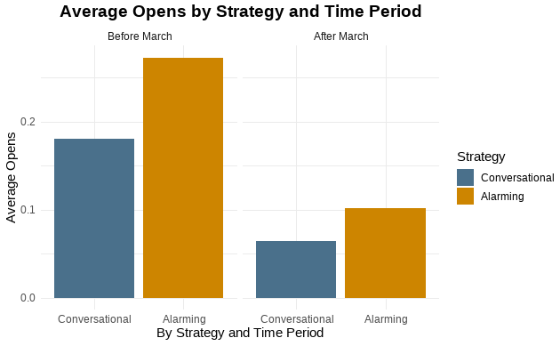

The chart showing Average Opens shows a much stronger Open response to the Alarming email type, indicating that customers were motivated to open the emails due to the sense of urgency in the message.

### Open to Click rate Statistics

Noting the differences in responses of our click rates vs our open rates, we would like a direct observation of the comparison. Elton also developed and analyzed the open to click ratios between Conversational and Alarming email types. The development of a box and whisker chart assists in the analysis of our ratio ranges and our customers engagement of the email types during both phases.

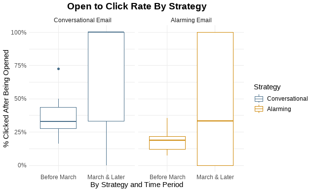

The graph “Open to Click Rate By Strategy” shows both time periods for Conversational Email on the left, and both time periods for Alarming Email on the right. We can clearly see that the box (representing the interquartile range) for the Before March category for Conversational is fully above the box for Alarming in the same time period. For the March & Later time period, though visually the boxes overlap, we can see by the median markers that the Conversational email strategy had a vastly higher percentage of customers clicking through after opening their emails than the Alarming email strategy did. This confirms the supposition inferred from the two earlier separate charts

### Unsubscribe Rate Statistics

We’ve observed customer engagement toward each email type, how often they clicked on emails, and how often they visited sites. How much of those email openings were actually due to the desire to unsubscribe? Kainen developed and conducted an analysis on our unsubscription data between the two email types to create a clearer understanding of this question.

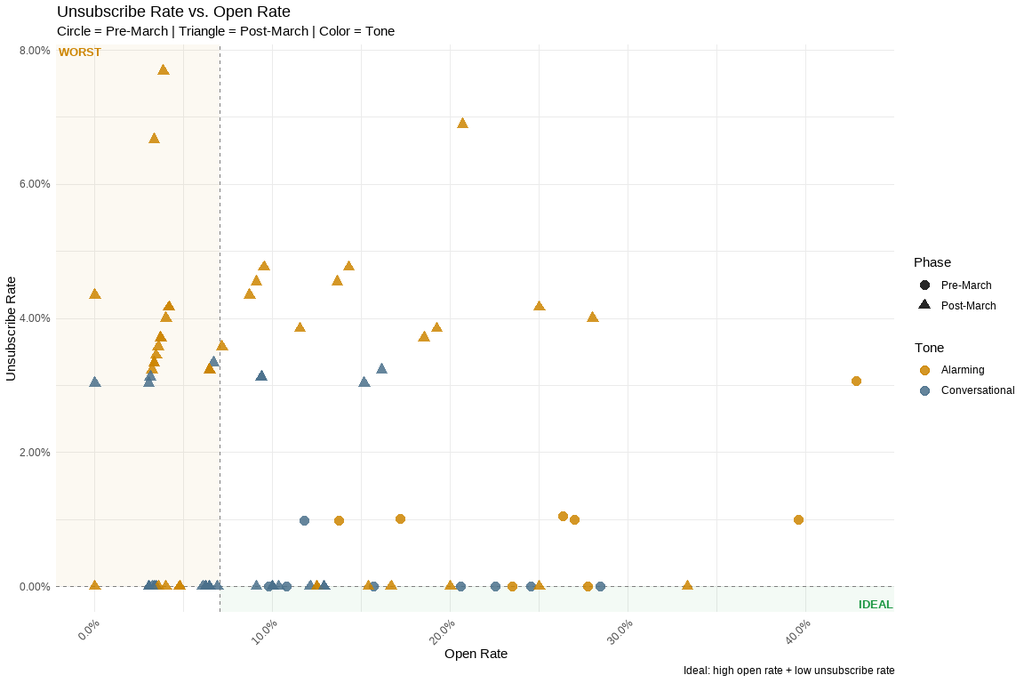

Each point represents a single email campaign send, with open rate on the x-axis and unsubscribe rate on the y-axis. Points in the ideal quadrant (high open, low unsub) represent the most effective campaigns, while points in the worst quadrant indicate email sends that failed to engage and possibly drove customers away. Coloring by tone and shaping by phase reveals whether Conversational or Alarming emails more consistently land in the ideal zone across both periods.

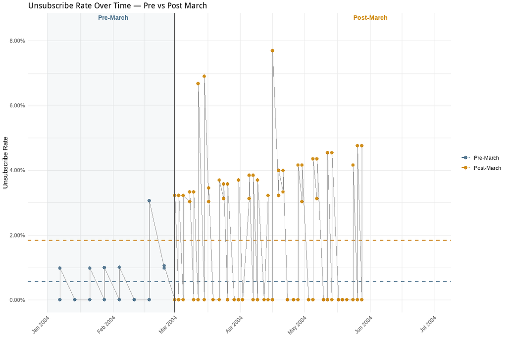

This scatter plot tracks unsubscribe rates across every campaign send from January through June 2004, with the data split into Pre and Post-March phases. The horizontal dashed lines represent the average unsubscribe rate for each phase, making it visible whether the strategic shift in March improved customer retention. A clear separation between phase averages would indicate that the change had a measurable impact on how customers responded to our emails.

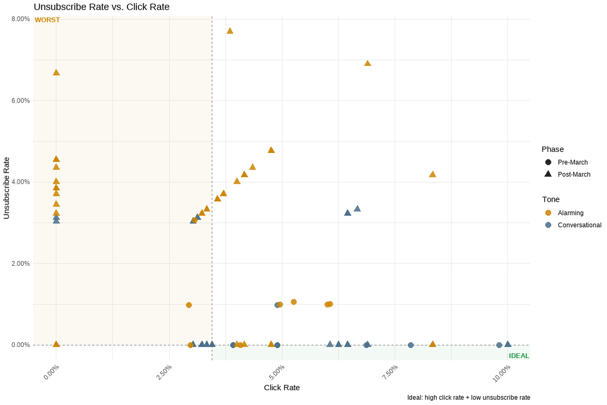

This scatter plot tracks whether campaigns that drive more clicks also tend to generate more unsubscribes, or whether the two metrics are independent of each other. Sends in the ideal quadrant achieve high click engagement without triggering unsubscribes, representing the most valuable campaigns. Comparing the distribution of Conversational versus Alarming sends across quadrants gives insight into which tone more reliably drives clicks without sacrificing list health.

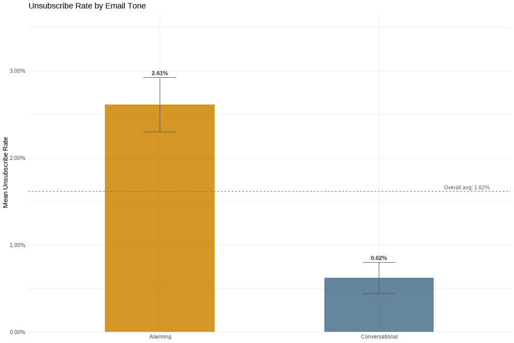

Comparing the mean unsubscribe rate between Conversational and Alarming tone groups reveals which email style is more likely to drive customers away. Error bars represent one standard error in each direction, accounting for any variability across sends. A meaningful gap between the two bars, particularly one that exceeds the error bar range, suggests that tone has a significant impact of customer behavior.

### Unsubscribe Rates Hypothesis Test

| tone | n | mean | sd | varience |
| --- | --- | --- | --- | --- |
| Alarming | 47 | 0.026148720 | 0.02158890 | 0.0004660807 |
| Conversational | 47 | 0.006219414 | 0.01247161 | 0.0001555411 |

```
Cohen's d

d estimate: 1.130431 (large)
95 percent confidence interval:
    lower     upper
0.6892229 1.5716390

Results Summary:
Conversational (Group A) mean unsub rate: 0.62%
Alarming (Group B) mean unsub rate: 2.61%
p-value: 0
Interpretation: Significant difference: tone affects unsubscribe rate
```

### Order Rate Statistics

We would like to know how each email type affects the rate in which customers are ordering our products.The analysis of ordering observations was constructed and analyzed by Bea. Creating an overlapping bar chart of total site visits and total order counts shows us the ratio of customers that are placing orders when they visit our site.

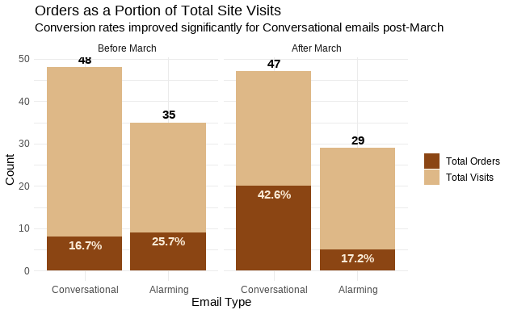

Observing this chart we can see a slightly higher order rate of 25.7% from alarming emails during the pre_march phase. However, post march, we see a dramatic increase in the percentage of orders to site visits from Conversational type emails. Conversational emails nearly tripling their percentage of orders, 42.6% total. While Alarming type emails drop from 25.7% to 17.2%. Telling us that customers engage with our casual, inviting emails when they are being sent multiple times a week, and they become severely less engaged with the Alarming Type emails.

The bar chart gives us a broad perspective on the insights of our customers orders. Lets look more closely at the intricacies of our customers engagement statistics. For a detailed perspective on our order insights, we’ve taken our previously calculated order rate, the ratio of orders to emails sent, and plotted the information to a box and whisker chart. This chart type provides the perspective of our average order rates based on email type, and the extremities of the order rates.

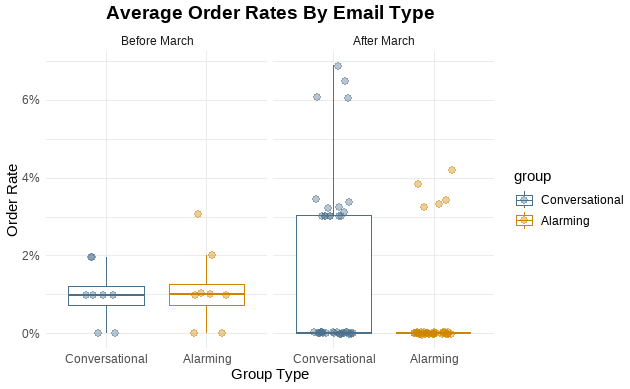

```r
ggplot(email_metric_with_sales, aes(x = group, y = orders_rate, color = group)) +
  geom_boxplot(outlier.shape = NA) +
  geom_jitter(width = 0.2, alpha = 0.4) +
  labs(x = "Group Type", y = "Order Rate", title = "Average Order Rates By Email Type")+
  facet_wrap(~ factor(before_march,
                      levels = c(TRUE, FALSE),
                      labels = c("Before March", "After March")))+
  scale_y_continuous(labels = percent_format())
```

Observing the chart, before March both of our email types have an average 1% order to email sent ratio, Alarming email types having a slightly higher extreme of order rates. This coincides with the analysis of the bar chart previously observed. However, when we look at post March charts, the data is very skewed. Our chart is accounting for to the larger percentage of orders that aren’t occurring, therefore, skewing the results. This information is important to note because it allows us to observe that there is a higher disparity of our clientele not placing orders due to the volume of emails being sent.

The skewed data is important to keep in mind, but we still desire to know our average client order rates when the data isn’t being skewed. Here we have created a chart that removes the skewing by only accounting for order rates above 0%.

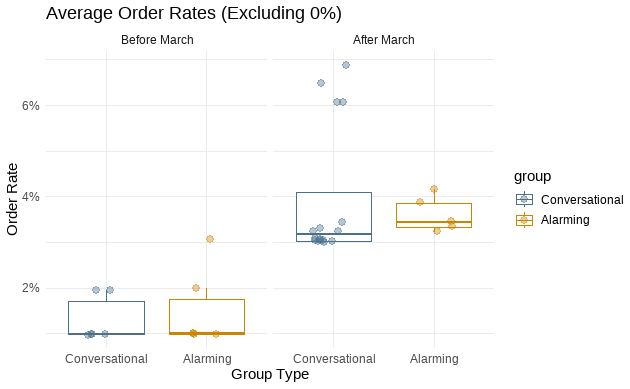

With the skewed data removed, we have a clearer image of our average order rates. Pre March, conversational and alarming type email remain to average their order rates around 1% with Alarming emails having a higher extremity of order rates. Post March, we see a substantially higher order rates in both email types. Conversational emails have a higher range of order rates with extremities past 6% of an order to emails sent ratio, and there is a higher quantity of order ratio points within the conversational type emails.

Thus, concluding that we have higher instances of orders and higher ratios of orders with conversational type emails when we are sending three of each email type out a week. Therefore, conversational type emails result in higher customer engagement.

### Sales Statistics

We’ve determined the engagement of the email types based on clicks, opens, subscriptions, and orders. Lastly we would like to analyze the reception of our email types based on sales and the time period in which they placed their orders. Bea and Kainen worked on the development of these visualizations and the analyses conducted. Using a scatter plot, created by Bea, with a trend line we’ve created a visual timeline of our sales based on the days emails were sent.

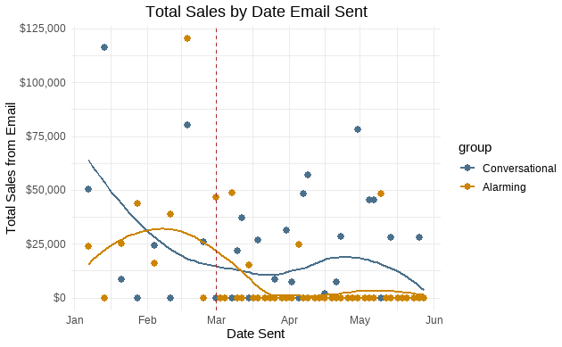

#### Analysis of Total Sales by Email Type

To confirm if there is actually a resurgence in Conversational type sales compared to Alarming type sales post March, we will conduct a Welch’s T-Test. Our test entails the sales data between Conversational and Alarming emails after March. Our Alternative Hypothesis is that there is a significant difference in the correlation of Conversational type email sales compared to Alarming type emails. Our NULL hypothesis is that there is no significant difference between the two.

```
    Welch Two Sample t-test

data:  sales_amount by group
t = 2.0859, df = 66.22, p-value = 0.04084
alternative hypothesis: true difference in means between group Conversational and group Alarming is not equal to 0
95 percent confidence interval:
   348.3161 15890.4326
sample estimates:
mean in group Conversational       mean in group Alarming
                    12845.84                      4726.47
```

This experiment is conducted with a confidence interval of 95% and we desire a p-value < 0.05 to reject the null hypothesis. By comparing p-values of the Welch’s T-test, 0.04 < 0.05, rejecting the null hypothesis, and proving that there is a significant difference in Conversational type sales compared to Alarming type sales.

We know for certainty that we experience more sales from Conversational type emails post March, but we would also like to know the average time frame it takes our customers to fully engage with our emails. The bar chart below, with an average sales line, was developed by Kainen.

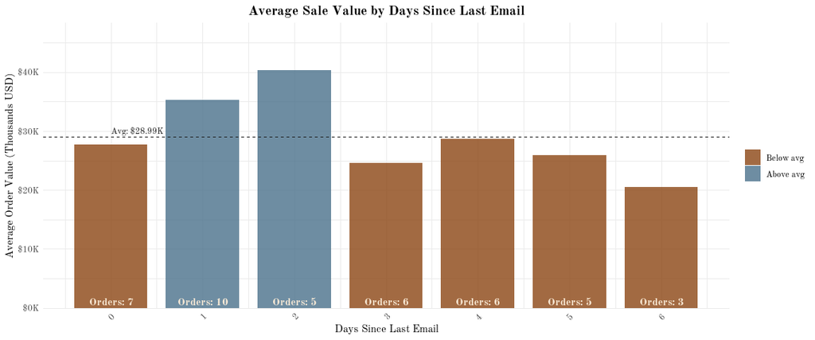

Our average sales between both email types are roughly 29k. The chart displays the number of days that pass before our clients place an order, and shows the number of orders that have occurred during that time frame. The day emails are sent out, and the day after we receive the most amount of orders.The day after having the highest count of 10. 3-4 days after has the third highest of orders, 6, but their sales remain below our average sales. Our emails have received above average sales 1-2 days after emails were sent. When we finalize the days we should send out emails, its important to keep in mind that we receive our highest grossing sales a few days after.

We need to determine the best day to send out emails to get the most engagement from our customers. To determine the best day to send out emails, we break down the bar chart above into sections based on the days emails have been sent. Keeping in mind that we receive the highest gross in sales 1-2 days after an email was sent. Bea created the Bar charts below, and they are segmented by the day the phase period as well, pre March and post March.

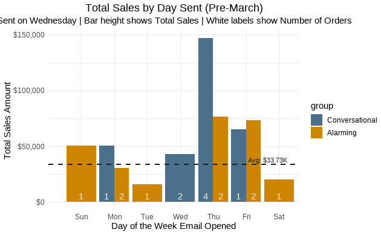

As observed in Kainen’s bar chart, we can confirm the pattern that more sales with higher grossing sales occur 1-2 days after the email was sent. In the case pre March, emails were only sent on Wednesdays. 6 orders were placed on Thursdays and 3 orders were placed on Fridays, in the 1-2 day range. The sales accumulated during these two days are also the highest grossing above our average sales amount. As observed in previous analyses, we note that we receive more orders from Alarming emails when emails are went once a week on Wednesdays, we receive higher sales from Conversational emails, and we receive the most orders and sales 1-2 days post email send dates.Next we look at the post March data.

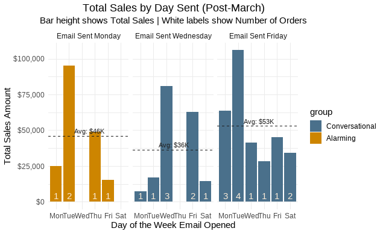

The post March bar chart displays is sectioned by the days emails were sent out, Monday, Wednesday, and Friday. From a general observation, we clearly see that Conversational emails are dominating in sales and order placement. The lack of orders from Alarming emails proves that customers do not engage with this type of email when it’s sent three times a week. However, we can note the success of Alarming type emails and their influence on customers when they’re only at the beginning of the week. Conversational type emails dominate the order and sales space with averages of 36k when sent on Wednesdays, and average sales of Friday type emails calculating to 53k.

#### Analysis of Total Sales by Day Email Sent

Note that we experience more customer engagement in Conversational type emails when they are sent three times a week. We would now like to determine if there is a statistical difference if we send emails on Wednesday as opposed to Friday. Our alternative hypothesis is that there is a statistical difference between sending conversational emails on Wednesday and Friday. The Null Hypothesis is that there is no statistical difference between the days we send the emails. To conduct this hypothesis we need to isolate the conversational sales data by sent dates on Wednesday and Friday,

```r
# Filter data before march, only conversational, and sent on wednesdays and fridays
t_test_data <- email_metric_with_sales %>%
  filter(before_march == FALSE,
         group == "Conversational",
         day_of_week %in% c("Wed", "Fri")) %>%
  #create a binary category based on if an order was placed
  mutate(order_status = ifelse(number_orders > 0, "Placed", "Not Placed"),
         day_of_week = as.factor(day_of_week)) %>%
  droplevels() # Removes lingering factors that were filtered out
```

To conduct the hypothesis we will be using a chi-squared test. To conduct this test we need a contingency table displaying the frequency in which orders were placed based on the day an email was sent. With the contingency table we can conduct a Chi-square test to determine if there is a statistical difference between the days emails were sent.

```
[1] "Contingency Table"

      Not Placed Placed
  Wed          7      6
  Fri          3     10

    Pearson's Chi-squared test with Yates' continuity correction

data:  contingency_table
X-squared = 1.4625, df = 1, p-value = 0.2265
```

Our p-value of 0.227 > 0.05. Therefore, we fail to reject the null hypothesis and determine that there is no significant difference between sending emails on Wednesday or Friday.

An alternative hypothesis test to determine the validity of the results between sending emails on a Wednesday or Friday is the Two Proportion Z-Test. However, our sample size isn’t greater than 30. Additionally, when conducting a Shapiro_Wilk test to determine if our order count data is normally distributed, our p-value < 0.05, indicating that our data isn’t normally distributed. Therefore, furthering the nullification of using the Two Proportion Z-Test.

```
    Shapiro-Wilk normality test

data:  t_test_data$number_orders
W = 0.79499, p-value = 0.0001449
```

### A/B Test Validity

With our Chi-Squared test showing there is no significant difference between sending emails on a Wednesday or Friday, and the Two Proportion Z-test rendering unusable due lack of data available, we are led to believe that this A/B test does not have enough data to fully conclude the results of test. We can conduct a power analysis test to give us an idea of the sample size we may need for this test. One analysis will be regarding the A/B test as a whole, the other will be regarding an A/B test for sending Conversational emails on a Wednesday or Friday.

To conduct this analysis, our Cohen’s D will be the differences between the order rates for both versions of A/B tests. Our alpha is 0.05, with the standard power of 80% chance of success. This information will be used to conduct our power t-test.

```
[1] "Whole A/B Test"

     Two-sample t test power calculation

              n = 50.58007
              d = 0.5625624
      sig.level = 0.05
          power = 0.8
    alternative = two.sided

NOTE: n is number in *each* group

[1] "Total Campaigns"

Group A Group B
     47      47
[1] "Conversational: Wed/Fri A/B test"

     Two-sample t test power calculation

              n = 130.5593
              d = 0.3480401
      sig.level = 0.05
          power = 0.8
    alternative = two.sided

NOTE: n is number in *each* group


Wed Fri
 13  13
```

Based on the Power analysis, Theoretically, We do not have a significant number or email campaigns sent to determine if there is a significance in receiving orders between sending Conversational emails and Alarming Emails. This determination is based on our power analysis of 50 campaigns per email type needed to conduct a viable test regarding a tones affect on orders. However, 47 email campaigns are close to 50, and previous hypothetical tests regarding unsubscription rates and sales show that Alarming emails lead to unsubscriptions and Conversational emails lead to more sales. Therefore showing there was significance between tones for the entire A/B test.

Observing the Power Analysis of the Conversational A/B test we’ve concluded that there is not a significant number of campaigns sent to determine the significance between sending Conversational type emails on either Wednesday or Friday. The power test suggests to have 131 campaigns sent on both Wednesday and Friday, we currently have 13. Therefore, we suggest to conduct an additional A/B test campaign, sending Conversational emails on both Wednesday and Friday until 131 campaigns are sent on both days.

## Conclusion and Next Steps

We’ve determined several insights based on our observations of customer engagements with clicks, opens, unsubscrptions, orders, and sales. With clicks we determined we receive more customer engagement with conversational type emails during both phases of A/B testing. Contrary to the click rate, Our site visits (open rates) receive more customer engagement with Alarming type emails. Telling us that Alarming type emails encourage the engagement of customers to access our website, but Conversational type emails influence the most general engagement with our sent emails. Analyzing the unsubscriptions to our emails, based on email types, we concluded that Alarming emails receive the most unsubscriptions, furthering our conclusion that our customers aren’t receiving our Alarming emails positively, even more so when we send them three times a week. Lastly, we observed customer engagement of each email type based on orders and sales. While Alarming emails produced the most orders when we sent emails only on Wednesday, Conversational emails took the stage with the amount of sales that were attributed to our company. Additionally, we determined the best time to send emails are on Wednesdays and Fridays, but we can’t determine for certainty which day would be the best. Concluding that, moving forward the best course of action is to send Conversational type emails on Wednesdays and Fridays. We also suggest to continue to tack the sales of our Conversational emails and our customer engagement towards the emails on Wednesdays and Fridays. Once we’ve sent 131 campaigns on both Wednesday and Friday, we can conduct another analytical test to refine our emails.